# Capstone Quiz I

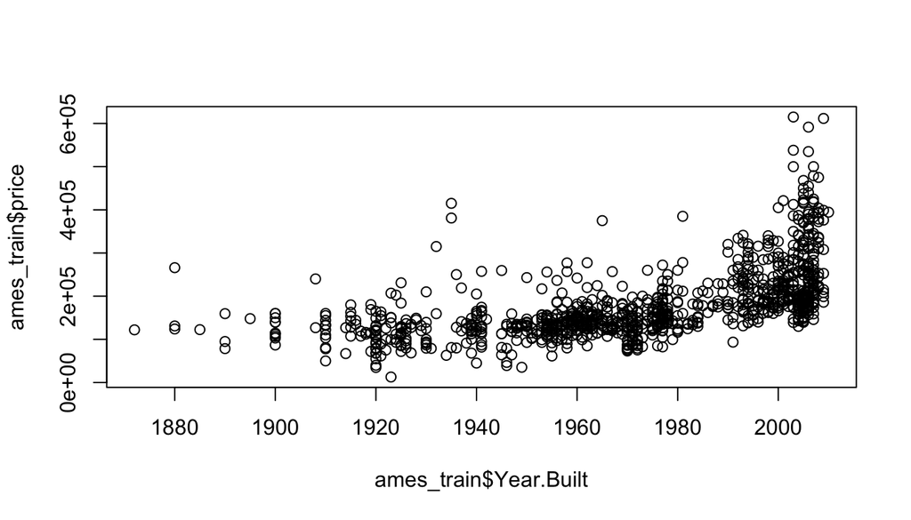

```r
plot(ames_train$Year.Built, ames_train$price)
```

```r
# answer: C
```

5. Suppose you are examining the relationship between `price` and `area`. Which of the following variable transformations makes the relationship appear to be the most linear?
   1. Do not transform either `price` or `area`
   2. Log-transform `price` but not `area`
   3. Log-transform `area` but not `price`
   4. Log-transform both `price` and `area`

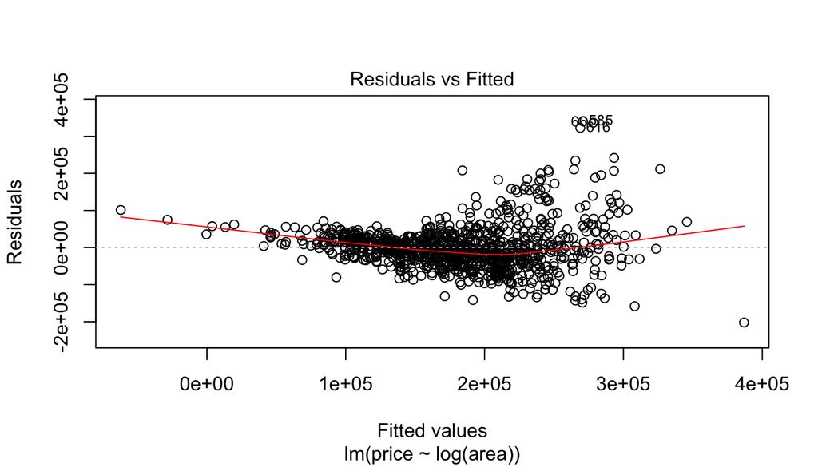

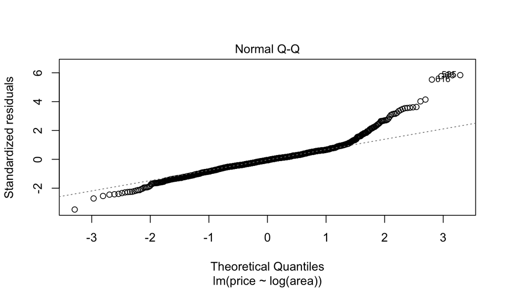

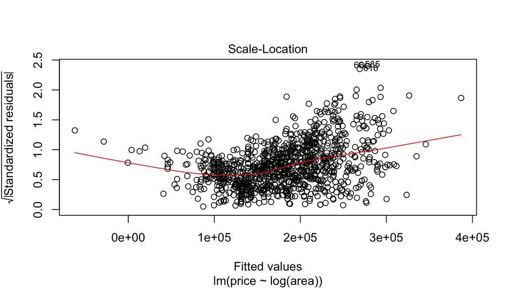

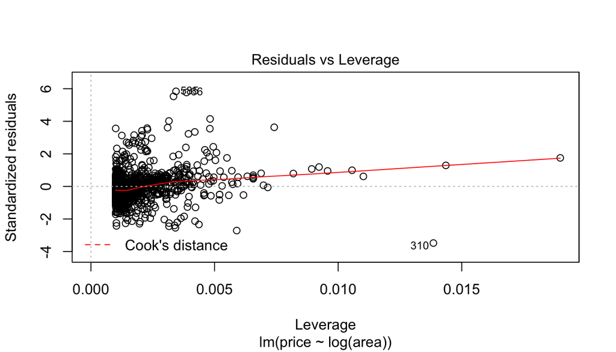

```r
# type your code for Question 5 here, and Knit

fit <- lm(price ~ log(area), data = ames_train)
fit1 <- lm(log(price) ~ area, data = ames_train)
fit2 <- lm(log(price) ~ log(area), data = ames_train)

plot(fit)
```

```r
anova(fit)
```

```
## Analysis of Variance Table
##
## Response: price
##            Df     Sum Sq    Mean Sq F value    Pr(>F)
## log(area)   1 3.2900e+12 3.2900e+12  962.15 < 2.2e-16 ***
## Residuals 998 3.4126e+12 3.4194e+09
## ---
## Signif. codes:  0 '***' 0.001 '**' 0.01 '*' 0.05 '.' 0.1 ' ' 1
```

```r
anova(fit1)
```

```
## Analysis of Variance Table
##
## Response: log(price)
##            Df Sum Sq Mean Sq F value    Pr(>F)
## area        1 90.300  90.300  1042.7 < 2.2e-16 ***
## Residuals 998 86.427   0.087
## ---
## Signif. codes:  0 '***' 0.001 '**' 0.01 '*' 0.05 '.' 0.1 ' ' 1
```

```r
anova(fit2)
```

```
## Analysis of Variance Table
##
## Response: log(price)
##            Df Sum Sq Mean Sq F value    Pr(>F)
## log(area)   1 96.598  96.598  1203.1 < 2.2e-16 ***
## Residuals 998 80.130   0.080
## ---
## Signif. codes:  0 '***' 0.001 '**' 0.01 '*' 0.05 '.' 0.1 ' ' 1
```

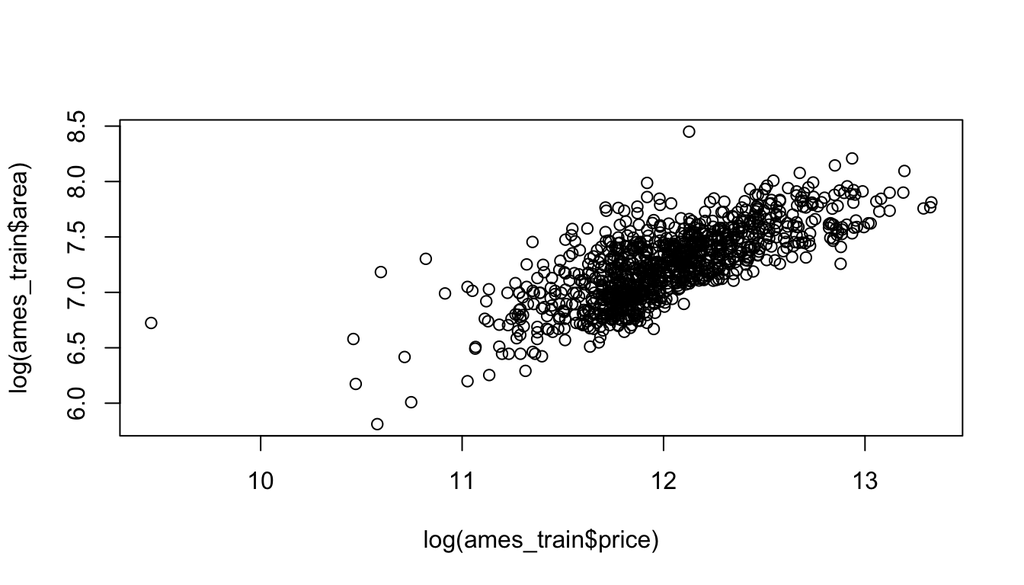

```r
# I compared F values for these tests. Option D is the largest.

plot(log(ames_train$price), log(ames_train$area))
```

6. Suppose that your prior for the proportion of houses that have at least one garage is Beta(9, 1). What is your posterior? Assume a beta-binomial model for this proportion.
   1. Beta(954, 46)
   2. Beta(963, 46)
   3. Beta(954, 47)
   4. Beta(963, 47)

```r
# type your code for Question 6 here, and Knit

sum(is.na(ames_train$Garage.Type))
```

```
## [1] 46
```

```r
length(ames_train$Garage.Type)
```

```
## [1] 1000
```

```r
1000 - 46
```

```
## [1] 954
```

```r
# Answer D
```

7. Which of the following statements is true about the dataset?
   1. Over 30 percent of houses were built after the year 1999.
   2. The median housing price is greater than the mean housing price.
   3. 21 houses do not have a basement.
   4. 4 houses are located on gravel streets.

```r
# type your code for Question 7 here, and Knit
sum(ames_train$Year.Built >= 1999) / length(ames_train$Year.Built) # 0.288
```

```
## [1] 0.288
```

```r
median(ames_train$price) > mean(ames_train$price) #False
```

```
## [1] FALSE
```

```r
sum(is.na(ames_train$Bsmt.Qual)) # 21
```

```
## [1] 21
```

```r
sum(ames_train$Street == "Grvl") # 3
```

```
## [1] 3
```

```r
# answer is C
```

8. Test, at the $\alpha = 0.05$ level, whether homes with a garage have larger square footage than those without a garage.
   1. With a p-value near 0.000, we reject the null hypothesis of no difference.
   2. With a p-value of approximately 0.032, we reject the null hypothesis of no difference.
   3. With a p-value of approximately 0.135, we fail to reject the null hypothesis of no difference.
   4. With a p-value of approximately 0.343, we fail to reject the null hypothesis of no difference.

```r
# type your code for Question 8 here, and Knit

with_gar <- ames_train %>% filter(ames_train$Garage.Cond !="NA") #weird syntax in r..
without_gar <- ames_train %>% filter(is.na(ames_train$Garage.Cond))
t.test(with_gar$area, without_gar$area)
```

```
##
##  Welch Two Sample t-test
##
## data:  with_gar$area and without_gar$area
## t = 4.7973, df = 51.643, p-value = 1.41e-05
## alternative hypothesis: true difference in means is not equal to 0
## 95 percent confidence interval:
##  191.4741 466.9128
## sample estimates:
## mean of x mean of y
##  1492.087  1162.894
```

```r
# the answer is A
```

9. For homes with square footage greater than 2000, assume that the number of bedrooms above ground follows a Poisson distribution with rate $\lambda$. Your prior on $\lambda$ follows a Gamma distribution with mean 3 and standard deviation 1. What is your posterior mean and standard deviation for the average number of bedrooms in houses with square footage greater than 2000 square feet?
   1. Mean: 3.61, SD: 0.11
   2. Mean: 3.62, SD: 0.16
   3. Mean: 3.63, SD: 0.09
   4. Mean: 3.63, SD: 0.91

```r
# type your code for Question 9 here, and Knit

# have hard time doing this one ...

more_than2000 <- ames_train %>% filter(area > 2000)

sum(more_than2000$Bedroom.AbvGr) / 138
```

```
## [1] 3.630435
```

```r
theta_n = 1 / (138+ 1)
```

10. When regressing $\log$(`price`) on $\log$(`area`), there are some outliers. Which of the following do the three most outlying points have in common?
    1. They had abnormal sale conditions.
    2. They have only two bedrooms.
    3. They have an overall quality of less than 3.
    4. They were built before 1930.

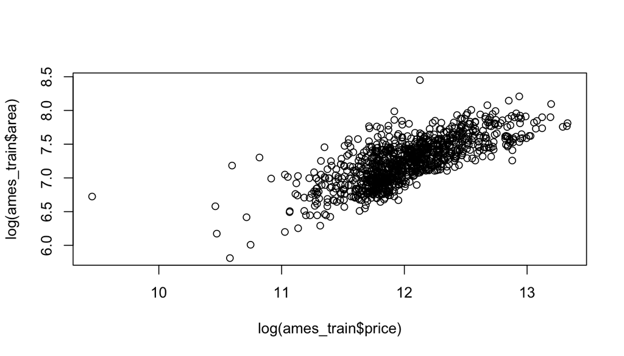

```
## numeric(0)
```

```r
# type your code for Question 10 here, and Knit
reg <- lm(log(ames_train$price) ~ log(ames_train$area))

plot(log(ames_train$price), log(ames_train$area)) + abline(log(ames_train$price), log(ames_train$area))
```

```r
print(reg)
```

```
##
## Call:
## lm(formula = log(ames_train$price) ~ log(ames_train$area))
##
## Coefficients:
##          (Intercept)  log(ames_train$area)
##               5.3444                0.9217
```

```r
obs_data <- data.frame(ames_train$PID,ames_train$price, ames_train$area)

obs_data$residuals <- residuals(reg)

obs_data$residuals <- obs_data$residuals ^ 2

# next step is to order the residuals descend..


obs_data[with(obs_data, order(-residuals)), ]
```

```
##      ames_train.PID ames_train.price ames_train.area    residuals
## 428       902207130            12789             832 4.348291e+00
## 741       911102170            40000            1317 1.872156e+00
## 206       903484080            50000            1484 1.575422e+00
## 310       908154205           184750            4676 1.012007e+00
## 559       902477120            34900             720 8.988884e-01
## 268       902402260            55000            1086 7.604958e-01
## 998       534427010            84900            1728 7.499690e-01
## 618       527252070           392000            1419 7.146361e-01
## 585       528150070           611657            2364 6.721475e-01
## 337       908204180            61500            1152 6.637971e-01
## 616       527216080           591587            2338 6.346928e-01
## 470       902330010           122000            2358 6.240405e-01
## 276       533350090           150000            2944 6.208161e-01
## 66        528164060           615000            2470 6.160196e-01
```

[output cut: 986 more lines]

```r
ames_train[ames_train$PID %in% c(902207130, 911102170, 903484080), ]
```

```
## # A tibble: 3 × 81
##         PID  area price MS.SubClass MS.Zoning Lot.Frontage Lot.Area Street
##       <int> <int> <int>       <int>    <fctr>        <int>    <int> <fctr>
## 1 903484080  1484 50000          50        RM           60    10320   Pave
## 2 902207130   832 12789          30        RM           68     9656   Pave
## 3 911102170  1317 40000          70   C (all)           50     8500   Pave
## # ... with 73 more variables: Alley <fctr>, Lot.Shape <fctr>,
## #   Land.Contour <fctr>, Utilities <fctr>, Lot.Config <fctr>,
## #   Land.Slope <fctr>, Neighborhood <fctr>, Condition.1 <fctr>,
## #   Condition.2 <fctr>, Bldg.Type <fctr>, House.Style <fctr>,
## #   Overall.Qual <int>, Overall.Cond <int>, Year.Built <int>,
## #   Year.Remod.Add <int>, Roof.Style <fctr>, Roof.Matl <fctr>,
## #   Exterior.1st <fctr>, Exterior.2nd <fctr>, Mas.Vnr.Type <fctr>,
## #   Mas.Vnr.Area <int>, Exter.Qual <fctr>, Exter.Cond <fctr>,
## #   Foundation <fctr>, Bsmt.Qual <fctr>, Bsmt.Cond <fctr>,
## #   Bsmt.Exposure <fctr>, BsmtFin.Type.1 <fctr>, BsmtFin.SF.1 <int>,
## #   BsmtFin.Type.2 <fctr>, BsmtFin.SF.2 <int>, Bsmt.Unf.SF <int>,
## #   Total.Bsmt.SF <int>, Heating <fctr>, Heating.QC <fctr>,
## #   Central.Air <fctr>, Electrical <fctr>, X1st.Flr.SF <int>,
## #   X2nd.Flr.SF <int>, Low.Qual.Fin.SF <int>, Bsmt.Full.Bath <int>,
## #   Bsmt.Half.Bath <int>, Full.Bath <int>, Half.Bath <int>,
## #   Bedroom.AbvGr <int>, Kitchen.AbvGr <int>, Kitchen.Qual <fctr>,
## #   TotRms.AbvGrd <int>, Functional <fctr>, Fireplaces <int>,
## #   Fireplace.Qu <fctr>, Garage.Type <fctr>, Garage.Yr.Blt <int>,
## #   Garage.Finish <fctr>, Garage.Cars <int>, Garage.Area <int>,
## #   Garage.Qual <fctr>, Garage.Cond <fctr>, Paved.Drive <fctr>,
## #   Wood.Deck.SF <int>, Open.Porch.SF <int>, Enclosed.Porch <int>,
## #   X3Ssn.Porch <int>, Screen.Porch <int>, Pool.Area <int>,
## #   Pool.QC <fctr>, Fence <fctr>, Misc.Feature <fctr>, Misc.Val <int>,
## #   Mo.Sold <int>, Yr.Sold <int>, Sale.Type <fctr>, Sale.Condition <fctr>
```

```r
# i am such a genius..
# the answer is C
```

11. Which of the following are reasons to log-transform `price` if used as a dependent variable in a linear regression?
    1. `price` is right-skewed.
    2. `price` cannot take on negative values.
    3. `price` can only take on integer values.
    4. Both a and b.

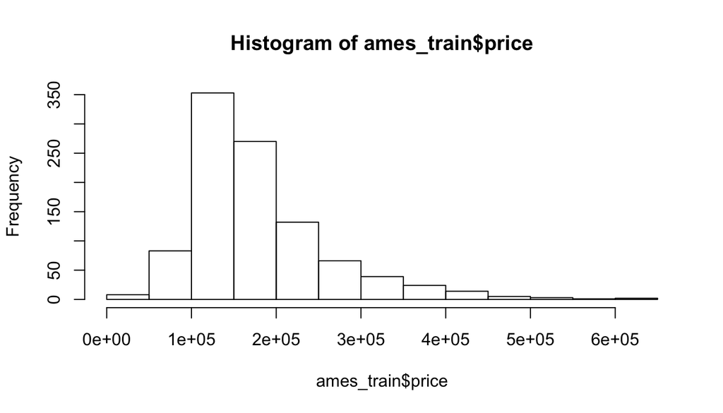

```r
# type your code for Question 11 here, and Knit

hist(ames_train$price)
```

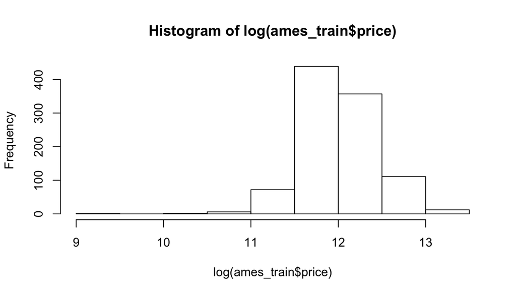

```r
hist(log(ames_train$price))
```

```r
# the answer is D

# it matters with the comsumption of linear regression:
# - the regressor's resuduals can take any value
# - in this case, it cannot take on negative values.
```

12. How many neighborhoods consist of only single-family homes? (e.g. `Bldg.Type` = `1Fam`)
    1. 0
    2. 1
    3. 2
    4. 3

```r
# type your code for Question 12 here, and Knit

cont_table <- ames_train %>% group_by(Neighborhood) %>% summarise(mean(Bldg.Type == "1Fam"))
print(cont_table)
```

```
## # A tibble: 27 × 2
##    Neighborhood `mean(Bldg.Type == "1Fam")`
##          <fctr>                       <dbl>
## 1       Blmngtn                   0.1818182
## 2       Blueste                   0.0000000
## 3        BrDale                   0.0000000
## 4       BrkSide                   0.9756098
## 5       ClearCr                   1.0000000
## 6       CollgCr                   0.9647059
## 7       Crawfor                   0.8620690
## 8       Edwards                   0.8000000
## 9       Gilbert                   0.9795918
## 10       Greens                   0.0000000
## # ... with 17 more rows
```

```r
# what does "mean" mean here...
# the answer is C
```

13. Using color, different plotting symbols, conditioning plots, etc., does there appear to be an association between $\log$(`area`) and the number of bedrooms above ground (`Bedroom.AbvGr`)?
    1. Yes
    2. No

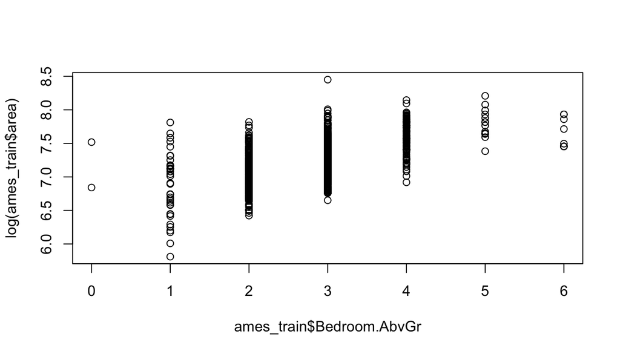

```r
# type your code for Question 13 here, and Knit

plot(log(ames_train$area) ~ ames_train$Bedroom.AbvGr)
```

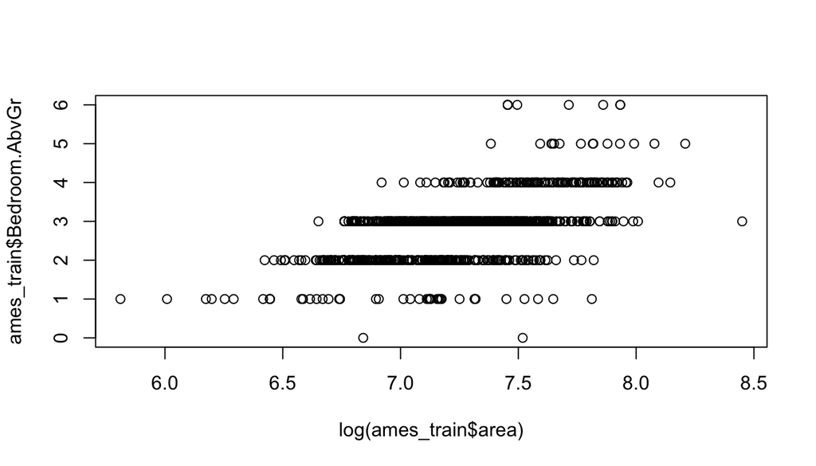

```r
plot(ames_train$Bedroom.AbvGr ~ log(ames_train$area))
```

```r
# Answer is Yes.
```

14. Of the people who have unfinished basements, what is the average square footage of the unfinished basement?
    1. 590.36
    2. 595.25
    3. 614.37
    4. 681.94

```r
# type your code for Question 14 here, and Knit

unfinished <- ames_train %>% filter(Bsmt.Unf.SF > 0) %>% summarise(mean(Bsmt.Unf.SF))

print(mean(ames_train$Bsmt.Unf.SF)) # not availiable.
```

```
## [1] NA
```

```r
print(unfinished) # 595.25
```

```
## # A tibble: 1 × 1
##   `mean(Bsmt.Unf.SF)`
##                 <dbl>
## 1            595.2527
```